# CLASE DEL 8 DE JULIO

## ITSM

El modelo operativo que transforma la capacidad tecnica en resultados de negocio.

Se enfoca en el ciclo de vida completo de los servicios de IT.

Gestiona la disponiblidad , el rendimiento y utilidad.

### PILARES

Se enfoca en las personas.

- Personas: Toda la estructura, y la cultura de servicio.
- Procesos: Flujo de trabajo estandarizados como gestion de incidentes, cambios o problemas.
- Tecnologia: Las herramientas como Jira Service Now, que automatizan y miden los prcesos.

### RELEVANCIA

- Mitigar el caos. Psar de una cultura de apaga fuegos.
- Alineación estrategica. Asegurar en el presupuesto y el esfruerzo de ingieria estan dedicados a servicios que realmenten e impactan
- Cumplimineto y gobernanza. Facitilitar auditorias y garantizar que los niveles de servicios se cumplan de manera sistematica. 0Osea mantener los SLAS a raya.

### RELACION CON ITIL.

- ITSM: Es la disiplica o practica es qel que hacemos.
- ITL: Es el marco de trabajo o framework, osea la biblioteca de **buenas practicas**.

"ITIL NO ES IMPLEMNTAR PROCESO, ES CAMBIAR COMO LA ORGANIZACION CREA VALOR CON TI."

### y EN GUate que pts

- Dependencias
- Burocracia
- Presupuesto
- Sistema legacy
- Alto impacto
- ((((((ellos))))))

### MESA DE TRABAJO

Es un call center. Osea es como el Resuelve. Ejemplo Service Desk.

Proposito

- Capturar la demanda de : Incidentes o solicitud de servicio normal.
- Actua como : El punto unico decontacto SPOC.
- Puerta de entrada a todos los servicios IT.

Funciones principales

- Proveer un canal claro para reportar problemas: Solicitar servicios, hacer consultas, reportar problemas.
- Gestionar solicitudes: Registro, Clasificacion, Asignación, Seguimiento de resolucion.

# CLASE 13 DE JULIO

Sin feedback solo veremos como nuestro0 sistema cada dia se deja de usar.

Servicios para usar

- Service Manage
- Service Now

**ITIL** significa **Information Technology Infrastructure Library** (Biblioteca de Infraestructura de Tecnologías de la Información).

Es un conjunto de **buenas prácticas** para gestionar los servicios de TI (Tecnologías de la Información), con el objetivo de que estos satisfagan las necesidades del negocio y de los usuarios.

### ¿Para qué sirve?

ITIL ayuda a las organizaciones a:

- Mejorar la calidad de los servicios de TI.
- Reducir costos y tiempos de resolución de problemas.
- Aumentar la satisfacción de los usuarios.
- Gestionar incidentes, cambios y riesgos de manera organizada.
- Estandarizar procesos de soporte y operación.

### Procesos importantes de ITIL

Algunos de los procesos más conocidos son:

- **Gestión de Incidentes:** Restaurar un servicio lo antes posible cuando ocurre un problema.
- **Gestión de Problemas:** Encontrar y eliminar la causa raíz de incidentes recurrentes.
- **Gestión de Cambios:** Controlar modificaciones en los sistemas para minimizar riesgos.
- **Gestión de Configuración:** Mantener un registro de los activos y componentes de TI.
- **Gestión de Niveles de Servicio (SLA):** Asegurar que los servicios cumplan los acuerdos establecidos con los clientes.

### Ejemplo

Si una empresa tiene un sistema de ventas que deja de funcionar:

1. Se registra el incidente.
2. El equipo de soporte lo resuelve para restaurar el servicio.
3. Si el problema ocurre repetidamente, se investiga la causa raíz.
4. Se implementa un cambio controlado para evitar que vuelva a suceder.

Ese flujo sigue las buenas prácticas de ITIL.

### ITIL 4

La versión más reciente es **ITIL 4**, que se enfoca en:

- Crear valor para el cliente.
- Agilidad y mejora continua.
- Integración con metodologías como **Agile**, **DevOps** y **Lean**.

### Respuesta corta para examen

> **ITIL (Information Technology Infrastructure Library)** es un conjunto de buenas prácticas para la gestión de servicios de TI que ayuda a planificar, entregar, operar y mejorar los servicios tecnológicos de una organización, alineándolos con las necesidades del negocio.

Dimensiones de servicio

En ITIL 4, las cuatro dimensiones de la gestión de servicios son:

- Organizaciones y Personas (Organizations and People) Se enfoca en las personas, sus habilidades, roles, estructura organizacional y cultura para ofrecer servicios de calidad.
- Información y Tecnología (Information and Technology) Incluye la información, bases de datos, aplicaciones, infraestructura, herramientas y tecnologías necesarias para gestionar y entregar los servicios.
- Socios y Proveedores (Partners and Suppliers) Considera a las organizaciones externas que proporcionan productos o servicios que apoyan la entrega del servicio.
- Flujos de Valor y Procesos (Value Streams and Processes) Define cómo se organizan las actividades y procesos para crear y entregar valor al cliente de forma eficiente.

### Indicadores de Valores adicinoales

- El valor tañe a otros indicadores como :

Eficiencia, Accesibilidad, Transparencia.

Los proyectos academicos y startups miden su retorno no por plata , sino que sea usado. Reducciones de tiempo

### Valor publico generado

- Eficencia y que no existan gatso.
- PVR o public value return.
- Transparencia y Confianza.
- Cobertura del Servicio
- Reducción del Riesgo

### NPS

Net Promotere Score

Cuando necesito saber el feedback del usuario. Cuando hago una medición.

Puede ser positivo o negativo.

- 0.4

o

-0.6

Tehndemos a ser mas juzgones y criticones. JJAAJAJA

Valor =( Eficiencia + Experiencia + Cobertrua + Confianza ) - ( Costos + Riesgos)

Y el valor publico debe ser mayor a 0. Si es igual a 0 es autosostenible

Autostenible es que almenos el resultado sea 0 Osea que los riesgos y riesgos son casi igual a la experiencia de3l usuario.

El valor no se entrega se co crea.

Participan

- Proveedor
- Consumidor
- Requiere colab activa
- Basado en el uso real del servicio.

Dirigido: Encuestas

No Dirigido: Uso

Una encuesta dirigida tiene que ser una normal.

Que tantas veces swe uso un dia me dice que tan relevante es para las personas.

### Producto

Configuración de recursos de una organización. Vechiculo por el cual doy valor.

Ejemplo:

- Plataformas web
- ERP
- Infraestructura cloud

Mejorar el producto no es siempre mejorar el servicio.

### Resultados Costos y Riesgos

- Funcionalidad o es muy dificil
- Hay una necesidad inexistent o que cambio en el tiempo.

|

# CLASE 15 de JULIO

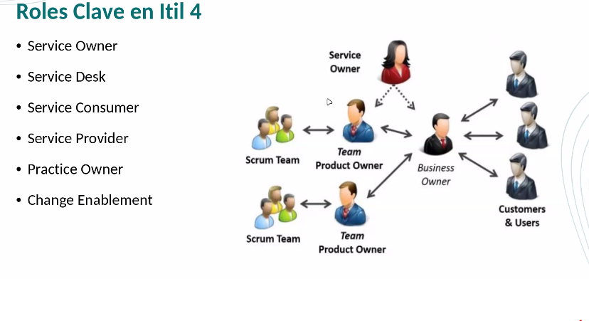

Practicer Owner es el que evalua si se cumplio o no con una de las 34 practicas de ITIL

[figure not shown]

En itil no nos interesa el producto sino el servicio que brinda.

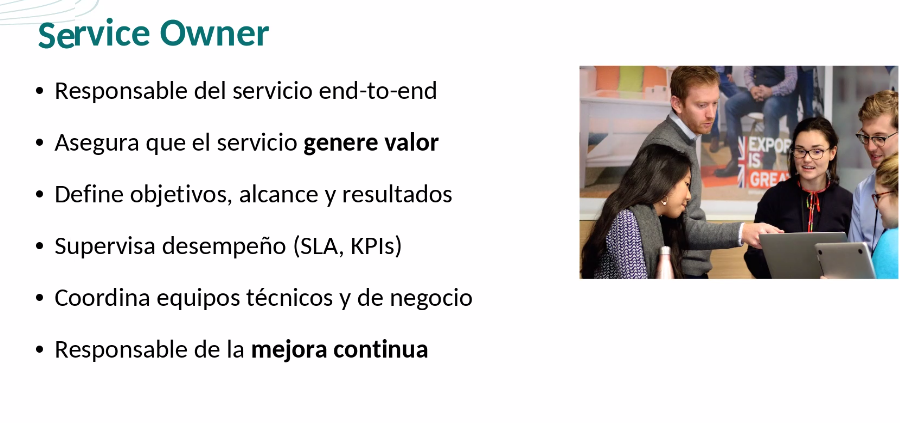

Este es como el product owner, vela porque se de lo que el cliente se necesita.

[figure not shown]

El se encarga de abrir el breach

Este es el que usa el servicio.

[figure not shown]

Un servicio es una iniciativa para que sea exitosa y funcione todos tenemos que estar involucrados

[figure not shown]

[figure not shown]

[figure not shown]

[figure not shown]

Busca que las cosas funcionen.

[figure not shown]

Resumenes

[figure not shown]

### DIMENSIONES

[figure not shown]

Al final los servicios son para que alguien los maneje.